# *I’ve Been Everywhere* Analysis

Noah A. Kouchekinia

Updated 2021-03-01

# 1 Introduction

This document extracts, visualizes, place names from the lyrics of Johnny Cash’s “I’ve Been Everywhere”, The objective of this document is to provide a sample of my coding as I preform a variety of data handling tasks. Code and comentary is displayed below. Unprocessed files can be found https://github.com/noahkouchekinia/I-ve_Been_Everywhere.

# 2 Extracting Place Data from Lyrics

The first step in the analysis is to extract location names from the unstructured text of the song lyrics.

In order to do this systematically and efficiently, I will rely on three common sense assumptions about the lyrics: 1. Although other aspects of the song are repetitive, lines with place names are not repeated. 2. Unlike most other song lyrics, place names are capitalized. 3. Place names will not include generic stop words.

```r
#I read in the lyrics from a text file as a character vector with an string for each line
  setwd("/home/noah/Documents/Code Samples/I-ve_Been_Everywhere")
  lyrics <- readLines("./Data/I've Been Everywhere.txt")

#Lets extract ngrams from the song
  #Eliminating blank or duplicated lines (first assumption)
    lines <- lyrics[! lyrics == ""] #We can eliminate blank lines
    lines <- lines[! lines %in% lines[duplicated(lines)]] #eliminate duplicate lines

  #Pulling out capitalized phrases (second assumption)
    library(stringr)
    phrases <- str_extract_all(lines, pattern = "([A-Z][a-z'\\-]+ ?)+")
    phrases <- unlist(phrases)
    phrases <- trimws(phrases)


  #Eliminating place names that include stop words (third assumption)
    library(stopwords)
    regex_stopwords <- paste(paste0(" ",paste(stopwords(), collapse = " | ")," "),
                             paste0("^",paste(stopwords(), collapse = " |^")," "),
                             paste0(" ",paste(stopwords(), collapse = "$| "),"$"),
                             paste0("^",paste(stopwords(), collapse = "$|^"),"$"),
                             sep = "|")
                                #^ these pastes make a long regex that will capture stopwords

    places <- phrases[-grep(regex_stopwords, tolower(phrases))] #removes phrases with stopwords

  #Lets look at our list
    places <- places[-duplicated(places)]
    places
```

```
##  [1] "Winnemucca"    "Mack"          "Listen"        "Reno"          "Chicago"       "Fargo"         "Minnesota"
##  [8] "Buffalo"       "Toronto"       "Winslow"       "Sarasota"      "Wichita"       "Tulsa"         "Ottawa"
## [15] "Oklahoma"      "Tampa"         "Panama"        "Mattawa"       "La Paloma"     "Bangor"        "Baltimore"
## [22] "Salvador"      "Amarillo"      "Tocopilla"     "Barranquilla"  "Padilla"       "Boston"        "Charleston"
## [29] "Dayton"        "Louisiana"     "Washington"    "Houston"       "Kingston"      "Texarkana"     "Monterey"
## [36] "Faraday"       "Santa Fe"      "Tallapoosa"    "Glen Rock"     "Black Rock"    "Little Rock"   "Oskaloosa"
## [43] "Tennessee"     "Hennessey"     "Chicopee"      "Spirit Lake"   "Grand Lake"    "Devil's Lake"  "Crater Lake"
## [50] "Pete's"        "Louisville"    "Nashville"     "Knoxville"     "Ombabika"      "Schefferville" "Jacksonville"
## [57] "Waterville"    "Costa Rica"    "Pittsfield"    "Springfield"   "Bakersfield"   "Shreveport"    "Hackensack"
## [64] "Cadillac"      "Fond"          "Lac"           "Davenport"     "Idaho"         "Jellico"       "Argentina"
## [71] "Diamantina"    "Pasadena"      "Catalina"      "Pittsburgh"    "Parkersburg"   "Gravelbourg"   "Colorado"
## [78] "Ellensburg"    "Rexburg"       "Vicksburg"     "El Dorado"     "Larimore"      "Admore"        "Haverstraw"
## [85] "Chatanika"     "Chaska"        "Nebraska"      "Alaska"        "Opelika"       "Baraboo"       "Waterloo"
## [92] "Kalamazoo"     "Kansas City"   "Sioux City"    "Cedar City"    "Dodge City"
```

It looks like a systematic handling of the song lyrics, aided by the stated assumptions, did an alright job pulling place names out of the song lyrics. However, it does look like there were some errors, two false positives and a false negative. Such is the messy reality of text data.

“Listen” and “Pete’s” were retained. They fit my assumptions even though they was not a place names. “Fond du Lac” was not included. It failed to meet my assumptions even though it was a place name. I manually correct these errors below

```r
#Removing false positives
  places <- places[! places %in% c("Listen", "Pete's")]

#Adding the place name Fond du Lac
  places <- places[! places %in% c("Fond","Lac")]
  places <- c(places, "Fond du Lac")
```

# 3 Geocode Function Writing

Just knowing place names is not particularly interesting. I want to get data about these places. I will use Google map’s API to get information about the locations we have extracted from song lyrics. I will write my own geocoding function to do so. There is a preexisting package with functions to interact with the Google maps API, however the function it includes is inflexible and the method of authentication is outdated.

```r
library(jsonlite)
vector_fromJSON <- Vectorize(fromJSON, SIMPLIFY = FALSE)

#Now lets write a geocoding function that returns a dataframe
  geocode <- function(locations,
                      regioncode = 'us',
                      APIkey){

      json_locations <- gsub(' ', '+', locations)

      response <- vector_fromJSON(paste0('https://maps.googleapis.com/maps/api/geocode/json?',
                                         'address=',
                                         json_locations,
                                         '&regioncode=', regioncode,
                                         '&key=', APIkey))

      response <- unlist(response, recursive = F)
      status <- response[grep('.status$',names(response))]
      status <- unlist(status)
      results <- response[grep('.results$',names(response))]

      lat       <- as.numeric(unlist(lapply(results, function(x){x$geometry$location$lat[1]})))
      lng       <- as.numeric(unlist(lapply(results, function(x){x$geometry$location$lng[1]})))

      address <- lapply(results,
                        function(x){address = data.frame(x$address_components[[1]]$long_name,
                                                         unlist(lapply(x$address_components[[1]]$types,
                                                                       paste,
                                                                       collapse = ", ")),
                                                         stringsAsFactors = FALSE)})
      address <- lapply(address,
                        function(x){names(x)<-c("comps", "types");x})

      country   <- unlist(lapply(address,
                                 function(x){ifelse(length(x$comps[grep('country',
                                                                        x$types)]) == 1,
                                                    x$comps[grep('country', x$types)],
                                                    NA)}))

      state   <- unlist(lapply(address,
                               function(x){ifelse(length(x$comps[grep('administrative_area_level_1',
                                                                      x$types
                                                                      )]) == 1,
                                           x$comps[grep('administrative_area_level_1',
                                                        x$types)],
                                            NA)}))

      county   <- unlist(lapply(address,
                                function(x){ifelse(length(x$comps[grep('administrative_area_level_2',
                                                                       x$types)]) == 1,
                                            x$comps[grep('administrative_area_level_2', x$types)],
                                            NA)}))

      locality <- unlist(lapply(address,
                                function(x){ifelse(length(x$comps[grep('locality',
                                                                       x$types)]) == 1,
                                            x$comps[grep('locality', x$types)],
                                            NA)}))

      df <- data.frame(locations,
                       lat,
                       lng,
                       locality,
                       county,
                       state,
                       country,
                       status,
                       stringsAsFactors = F)

      names(df) <- c("locations",
                     "lat",
                     "lng",
                     "locality",
                     "county",
                     "state",
                     "country",
                     "geocode_status")

      rownames(df) <- 1:nrow(df)

      return(df)
                                      }
```

Now I can run my function on all the places we extracted from the song.

```r
places <- geocode(locations = places, APIkey = Noahs_APIkey)

View(places)
```

| locations | lat | lng | locality | county | state | country | geocode_status |
| --- | --- | --- | --- | --- | --- | --- | --- |
| Winnemucca | 40.972958 | -117.73568 | Winnemucca | Humboldt County | Nevada | United States | OK |
| Mack | 36.077470 | -96.05270 | Tulsa | Tulsa County | Oklahoma | United States | OK |
| Reno | 39.529633 | -119.81380 | Reno | Washoe County | Nevada | United States | OK |
| Chicago | 41.878114 | -87.62980 | Chicago | Cook County | Illinois | United States | OK |
| Fargo | 46.877186 | -96.78980 | Fargo | Cass County | North Dakota | United States | OK |
| Minnesota | 46.729553 | -94.68590 | NA | NA | Minnesota | United States | OK |
| Buffalo | 42.886447 | -78.87837 | Buffalo | Erie County | New York | United States | OK |
| Toronto | 43.653226 | -79.38318 | Toronto | Toronto Division | Ontario | Canada | OK |
| Winslow | 35.024187 | -110.69736 | Winslow | Navajo County | Arizona | United States | OK |
| Sarasota | 27.336435 | -82.53065 | Sarasota | Sarasota County | Florida | United States | OK |
| Wichita | 37.687176 | -97.33005 | Wichita | Sedgwick County | Kansas | United States | OK |
| Tulsa | 36.153982 | -95.99277 | Tulsa | Tulsa County | Oklahoma | United States | OK |
| Ottawa | 45.421530 | -75.69719 | Ottawa | Ottawa Division | Ontario | Canada | OK |
| Oklahoma | 35.467560 | -97.51643 | Oklahoma City | Oklahoma County | Oklahoma | United States | OK |
| Tampa | 27.950575 | -82.45718 | Tampa | Hillsborough County | Florida | United States | OK |
| Panama | 8.537981 | -80.78213 | NA | NA | NA | Panama | OK |
| Mattawa | 46.737910 | -119.90282 | Mattawa | Grant County | Washington | United States | OK |
| La Paloma | 34.017499 | -118.27838 | Los Angeles | Los Angeles County | California | United States | OK |
| Bangor | 44.801613 | -68.77123 | Bangor | Penobscot County | Maine | United States | OK |
| Baltimore | 39.290385 | -76.61219 | Baltimore | NA | Maryland | United States | OK |
| Salvador | -12.977749 | -38.50163 | NA | Salvador | State of Bahia | Brazil | OK |
| Amarillo | 35.221997 | -101.83130 | Amarillo | Potter County | Texas | United States | OK |
| Tocopilla | -22.088678 | -70.19605 | Tocopilla | Tocopilla Province | Antofagasta | Chile | OK |
| Barranquilla | 11.004107 | -74.80698 | Barranquilla | Barranquilla | Atlantico | Colombia | OK |
| Padilla | 37.689663 | -97.32099 | Wichita | Sedgwick County | Kansas | United States | OK |
| Boston | 42.360082 | -71.05888 | Boston | Suffolk County | Massachusetts | United States | OK |
| Charleston | 32.776475 | -79.93105 | Charleston | Charleston County | South Carolina | United States | OK |
| Dayton | 39.758948 | -84.19161 | Dayton | Montgomery County | Ohio | United States | OK |
| Louisiana | 30.984298 | -91.96233 | NA | NA | Louisiana | United States | OK |
| Washington | 47.751074 | -120.74014 | NA | NA | Washington | United States | OK |

[output cut: 63 more lines]

# 4 Mapping “Everywhere”

R has some marvelous packages to create maps. Let’s map where Cash has been.

```r
#Now let's use leaflet to plot
    map <- leaflet(width = '100%',
                   options = leafletOptions())
    map <- addProviderTiles(map,
                            providers$CartoDB.Positron)
    map <- setView(map, lng = -102, lat = 30, zoom = 2)
    map <- addMarkers(map,
                      data = places[localities,],
                      lng = ~lng,
                      lat = ~lat,
                      label = ~locations
                    )
 map <- addPolygons(map,
                      data = country_shapes,
                      fillColor = "Orange",
                      weight = 2,
                      opacity = 1,
                      color = "Orange",
                      dashArray = "3",
                      fillOpacity = 0.7,
                      label = ~CNTRY_NAME,
                      highlight = highlightOptions(
                                  weight = 2,
                                  color = "white",
                                  dashArray = "3",
                                  fillOpacity = 0.75,
                                  bringToFront = TRUE)
                    )
 map <- addPolygons(map,
                      data = state_shapes,
                      fillColor = "Green",
                      weight = 2,
                      opacity = 1,
                      color = "Green",
                      dashArray = "3",
                      label = ~NAME,
                      fillOpacity = 0.7,
                      highlight = highlightOptions(
                                  weight = 2,
                                  color = "white",
                                  dashArray = "3",
                                  fillOpacity = 0.75,
                                  bringToFront = TRUE)
                    )

 map
```

[interactive chart not shown]

Fancy mapping packages are good fun. However it is often more sensible to make a well designed static image. Below, I make a similar map, relying only on trusty ggplot2.

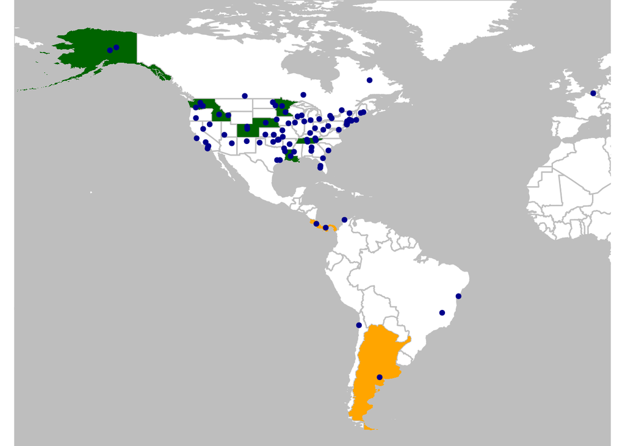

```r
library(ggplot2)
library(broom)

#Convert to plain dfs, as ggplot expects
state_df <- tidy(state_map, region = "STUSPS")
country_df <- tidy(country_map, region = "CNTRY_NAME")

#Plot
ggplot()+
  geom_polygon(data = country_df, aes(long,lat,group=group), fill = "white", col = "grey")+
  geom_polygon(data = state_df, aes(long,lat,group=group), fill = "white", col = "grey")+
  geom_polygon(data = state_shapes, aes(long,lat,group=group), fill="Dark Green", col = NA)+
  geom_polygon(data = country_shapes, aes(long,lat,group=group),fill="Orange", col = NA)+
  geom_jitter(data = places[localities,], aes(lng, lat), color = "Dark Blue")+
  theme_void()+
  theme(plot.background = element_rect(fill = "grey", color = NA))+
  coord_quickmap(xlim = c(-180,10), ylim =c(-60,80), clip = "on", expand = FALSE)
```

# 5 Why has Cash been where he has been?

As one can see from the Map above, Jonny Cash has been plenty of places. He has not, however, been *everywhere*. This begs the question, why did Cash go where he went? Below, this question is tackled with a logistic regression.

The level of analysis is US counties. Excellent county by county data is available for the US. Additionally, the bulk of places named in the song can be pinpointed to US counties. However, This means that the model have to take into account locations fromt he song that fall outside the US, or locations that include several counties, i.e. states.

The model uses three variables:

1. Population. It seems likely that Cash will go where there are people for which to preform.
2. Percent of Population Employed in Cattle Ranching. Cash maintained an image as a cow boy. It seems likely he would want to be seen among real cowboys.
3. Percent of Population Incarcerated. Cash famously preformed at Prison’s around the county. It seems likely that he would have been where the prisons were.

County by county population data is taken from the ACS. the number of ranchers is taken from the EEO survey. The number of incarcerated is taken from the census. Because the first two measures are estimates, they are not available for sparsely populated counties. We will only be considering counties for which we have data for all three variables. (Essentially, this is the largest third of US Counties).

```r
library(DescTools)

Population <-read.csv("./Data/Population.csv")
Ranchers <-read.csv("./Data/Ranchers.csv")
Prisoners <-read.csv("./Data/Prison Population.csv")

counties <- merge(Prisoners, merge(Population, Ranchers, by = 'Geography'), by = 'Geography')
names(counties)<-c('names','prison','pop','ranch')
counties$prison <- counties$prison/counties$pop
counties$ranch  <- counties$ranch/counties$pop

counties$visited <- ifelse(counties$names %in% paste0(places$county,", ",places$state), 1, 0)

model <- glm(visited ~ pop + prison + ranch,
             data = counties,
             family = binomial(link = "logit")
)
summary(model)
```

```
##
## Call:
## glm(formula = visited ~ pop + prison + ranch, family = binomial(link = "logit"),
##     data = counties)
##
## Deviance Residuals:
##     Min       1Q   Median       3Q      Max
## -1.2042  -0.3148  -0.2992  -0.2894   2.5814
##
## Coefficients:
##               Estimate Std. Error z value Pr(>|z|)
## (Intercept) -3.270e+00  2.431e-01 -13.453  < 2e-16 ***
## pop          8.621e-07  2.165e-07   3.982 6.84e-05 ***
## prison      -2.459e+00  1.074e+01  -0.229    0.819
## ranch        3.729e+01  5.769e+01   0.646    0.518
## ---
## Signif. codes:  0 '***' 0.001 '**' 0.01 '*' 0.05 '.' 0.1 ' ' 1
##
## (Dispersion parameter for binomial family taken to be 1)
##
##     Null deviance: 399.38  on 966  degrees of freedom
## Residual deviance: 379.31  on 963  degrees of freedom
## AIC: 387.31
##
## Number of Fisher Scoring iterations: 6
```

```r
DescTools::PseudoR2(model)
```

```
##   McFadden
## 0.05025357
```

It makes sense that this model would have little explanatory power. Johnny Cash did not actually write the song. It’s a cover.